# Experimental Design

Bis335

## Contents

### Part I: Design of Experimental Arrangement

- The elements of experimental design
- Typical methods in experimental arrangement

### Part II: Statistical Analysis of Experimental Design

- One-way layout analysis
- Two-way layout analysis
- Randomized block design analysis

### (Extra Issues: Hayter’s book) - Not included in this tutorial

- Friedman test: non parametric version of Randomized Block Design
- Expansion to three or more factor design
- Multiple-factor layout analysis

## Tutorial

### Design of Experimental Arrangement (s6)

#### Completely randomized design (s6)

The primary goal of experimental designs is to compare different treatments. In a completely randomized design (*CRD*), experimental units from a single homogeneous group are assigned at random to treatments. (Experimental units are individuals to which treatments are applied). If all the treatment groups have the same number of experimental units we call the design **balanced**.

Suppose that we are trying to find the effect of an enzyme on the output yields in cells with the four concentration levels of the enzyme. Make a $4 \times 4$ table with proper identification name on each column, row, and cell for each design below.

1. A complete balanced randomized design (*CRD*) with 4 replications

you cultured a cell type in 16 culture dishes for your experiment. Now you are designing a perfectly balanced random design with four replicas. To get the design, first assign random numbers to the 16 dishes, then sample four dishes four times according to the number of repetitions.

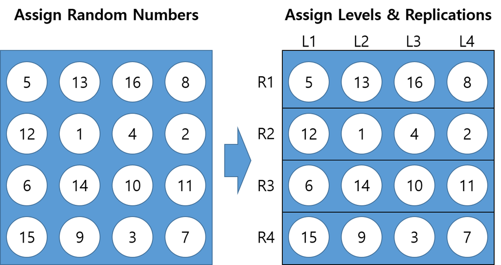

```r
# Design
set.seed(123)
dish <- 1:16
rn <- sample(dish, 16, replace = FALSE) # random permutation
rep <- cbind(rn[1:4], rn[5:8], rn[9:12], rn[13:16])
colnames(rep) <- c("L1", "L2", "L3", "L4") # levels of the enzyme
rownames(rep) <- c("R1", "R2", "R3", "R4") # replications
knitr::kable(rep)
```

|  | L1 | L2 | L3 | L4 |
| --- | --- | --- | --- | --- |
| R1 | 5 | 13 | 16 | 8 |
| R2 | 12 | 1 | 4 | 2 |
| R3 | 6 | 14 | 10 | 11 |
| R4 | 15 | 9 | 3 | 7 |

Now we are going to analyze this design with synthetic data which only depends on the treatment effect. As expected, the yield of the cell is different in terms of the level of enzyme but not significantly different in terms of the replication.

```r
# Data
rn <- data.frame(rn, c(rep("L1", 4), rep("L2", 4), rep("L3", 4), rep("L4", 4)),
            rep(c("R1","R2","R3","R4"), 4))
colnames(rn)<- c("Dish_Number", "Levels", "Replications")

yield <- c(runif(4, min = 150, max = 250),
           runif(4, min = 100, max = 200),
           runif(4, min = 200, max = 300),
           runif(4, min = 145, max = 155))
data <- data.frame(rn, yield)
colnames(data)<- c("Dish_Number", "Treatments", "Replicate", "Response"); data
```

```
##    Dish_Number Treatments Replicate Response
## 1            5         L1        R1 174.6088
## 2           12         L1        R2 154.2060
## 3            6         L1        R3 182.7921
## 4           15         L1        R4 245.4504
## 5           13         L2        R1 188.9539
## 6            1         L2        R2 169.2803
## 7           14         L2        R3 164.0507
## 8            9         L2        R4 199.4270
## 9           16         L3        R1 265.5706
## 10           4         L3        R2 270.8530
## 11          10         L3        R3 254.4066
## 12           3         L3        R4 259.4142
## 13           8         L4        R1 147.8916
## 14           2         L4        R2 146.4711
## 15          11         L4        R3 154.6302
## 16           7         L4        R4 154.0230
```

```r
str(data)
```

```
## 'data.frame':    16 obs. of  4 variables:
##  $ Dish_Number: int  5 12 6 15 13 1 14 9 16 4 ...
##  $ Treatments : Factor w/ 4 levels "L1","L2","L3",..: 1 1 1 1 2 2 2 2 3 3 ...
##  $ Replicate  : Factor w/ 4 levels "R1","R2","R3",..: 1 2 3 4 1 2 3 4 1 2 ...
##  $ Response   : num  175 154 183 245 189 ...
```

```r
# ANOVA Analysis
fit <- aov(Response ~ Treatments + Replicate, data = data)
summary(fit)
```

```
##             Df Sum Sq Mean Sq F value   Pr(>F)
## Treatments   3  27061    9020  22.430 0.000164 ***
## Replicate    3   2056     685   1.704 0.235212
## Residuals    9   3619     402
## ---
## Signif. codes:  0 '***' 0.001 '**' 0.01 '*' 0.05 '.' 0.1 ' ' 1
```

```r
TukeyHSD(fit)
```

```
##   Tukey multiple comparisons of means
##     95% family-wise confidence level
##
## Fit: aov(formula = Response ~ Treatments + Replicate, data = data)
##
## $Treatments
##              diff        lwr        upr     p adj
## L2-L1   -8.836308  -53.10384  35.431219 0.9220641
## L3-L1   73.296817   29.02929 117.564344 0.0026915
## L4-L1  -38.510299  -82.77783   5.757228 0.0919670
## L3-L2   82.133125   37.86560 126.400652 0.0012181
## L4-L2  -29.673991  -73.94152  14.593536 0.2262619
## L4-L3 -111.807116 -156.07464 -67.539589 0.0001189
##
## $Replicate
##            diff       lwr      upr     p adj
## R2-R1 -9.053601 -53.32113 35.21393 0.9169163
## R3-R1 -5.286321 -49.55385 38.98121 0.9812200
## R4-R1 20.322413 -23.94511 64.58994 0.5114975
## R3-R2  3.767280 -40.50025 48.03481 0.9929717
## R4-R2 29.376014 -14.89151 73.64354 0.2328807
## R4-R3 25.608734 -18.65879 69.87626 0.3307793
```

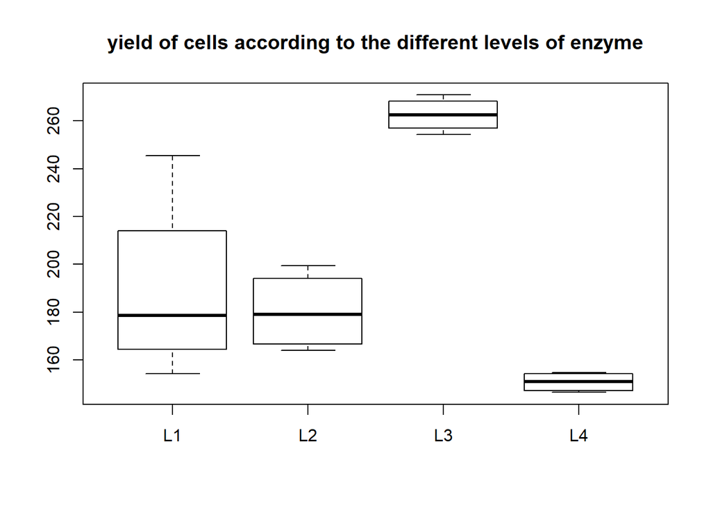

```r
boxplot(Response ~ Treatments, data = data,
        main = "yield of cells according to the different levels of enzyme")
```

```r
# cf
anova(lm(Response ~ Treatments + Replicate, data = data))
```

```
## Analysis of Variance Table
##
## Response: Response
##            Df  Sum Sq Mean Sq F value    Pr(>F)
## Treatments  3 27060.8  9020.3  22.430 0.0001636 ***
## Replicate   3  2055.9   685.3   1.704 0.2352124
## Residuals   9  3619.4   402.2
## ---
## Signif. codes:  0 '***' 0.001 '**' 0.01 '*' 0.05 '.' 0.1 ' ' 1
```

#### Randomized complete block design (s6)

2. A random block design (*RBD*) with four types of cells that may have confounding effects on the difference in enzyme effect. (sample size of 4)

In *CRD*, we have to assume that the cells in each dish are equivalent. In reality, even when the experimenter try to minimize any difference, they could be different due to the different culture conditions (for example, temperature gradient in the incubator) A powerful alternative to the *CRD* is to restrict the randomization process to form blocks. Within a block, we want all the treatment levels to be represented.

To assign treatments to experimental units, we need to work each block separately. The key element is that each treatment level appears in each block (forming complete blocks), and were assigned at random within each block. Because the cell type is the source of variation in this problem, we set the cell type as blocking variable and perform randomization within each block.

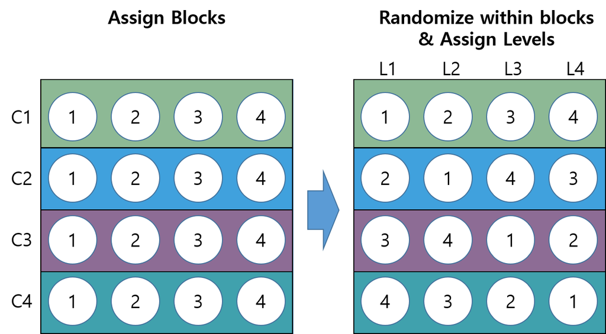

```r
# Design
set.seed(123)
dish <- 1:16
rn <- sample(dish, 16, replace = FALSE)
rn <- data.frame(rn, c(rep("L1", 4), rep("L2", 4), rep("L3", 4), rep("L4", 4)),
            rep(c("C1","C2","C3","C4"), 4))
colnames(rn)<- c("Dish_Number", "Enzyme_Level", "Cell_Type"); rn
```

```
##    Dish_Number Enzyme_Level Cell_Type
## 1            5           L1        C1
## 2           12           L1        C2
## 3            6           L1        C3
## 4           15           L1        C4
## 5           13           L2        C1
## 6            1           L2        C2
## 7           14           L2        C3
## 8            9           L2        C4
## 9           16           L3        C1
## 10           4           L3        C2
## 11          10           L3        C3
## 12           3           L3        C4
## 13           8           L4        C1
## 14           2           L4        C2
## 15          11           L4        C3
## 16           7           L4        C4
```

```r
rep <- data.frame(rn[rn$Cell_Type == "C1", "Dish_Number"],  # Block 1
                  rn[rn$Cell_Type == "C2", "Dish_Number"],  # Block 2
                  rn[rn$Cell_Type == "C3", "Dish_Number"],  # Block 3
                  rn[rn$Cell_Type == "C4", "Dish_Number"])  # Block 4

colnames(rep) <- c("L1", "L2", "L3", "L4") # levels of the enzyme
rownames(rep) <- c("B1", "B2", "B3", "B4") # blocks
knitr::kable(rep)
```

|  | L1 | L2 | L3 | L4 |
| --- | --- | --- | --- | --- |
| B1 | 5 | 12 | 6 | 15 |
| B2 | 13 | 1 | 14 | 9 |
| B3 | 16 | 4 | 10 | 3 |
| B4 | 8 | 2 | 11 | 7 |

The analysis procedure of the *RBD* is the same as *CRD* but here we consider the effect of blocking variable.

```r
# Data
yield <- c(runif(4, min = 150, max = 250),
           runif(4, min = 100, max = 200),
           runif(4, min = 200, max = 300),
           runif(4, min = 145, max = 155))
data <- data.frame(rn, yield)
colnames(data)<- c("Dish_Number", "Treatments", "Block", "Response"); data
```

```
##    Dish_Number Treatments Block Response
## 1            5         L1    C1 174.6088
## 2           12         L1    C2 154.2060
## 3            6         L1    C3 182.7921
## 4           15         L1    C4 245.4504
## 5           13         L2    C1 188.9539
## 6            1         L2    C2 169.2803
## 7           14         L2    C3 164.0507
## 8            9         L2    C4 199.4270
## 9           16         L3    C1 265.5706
## 10           4         L3    C2 270.8530
## 11          10         L3    C3 254.4066
## 12           3         L3    C4 259.4142
## 13           8         L4    C1 147.8916
## 14           2         L4    C2 146.4711
## 15          11         L4    C3 154.6302
## 16           7         L4    C4 154.0230
```

```r
str(data)
```

```
## 'data.frame':    16 obs. of  4 variables:
##  $ Dish_Number: int  5 12 6 15 13 1 14 9 16 4 ...
##  $ Treatments : Factor w/ 4 levels "L1","L2","L3",..: 1 1 1 1 2 2 2 2 3 3 ...
##  $ Block      : Factor w/ 4 levels "C1","C2","C3",..: 1 2 3 4 1 2 3 4 1 2 ...
##  $ Response   : num  175 154 183 245 189 ...
```

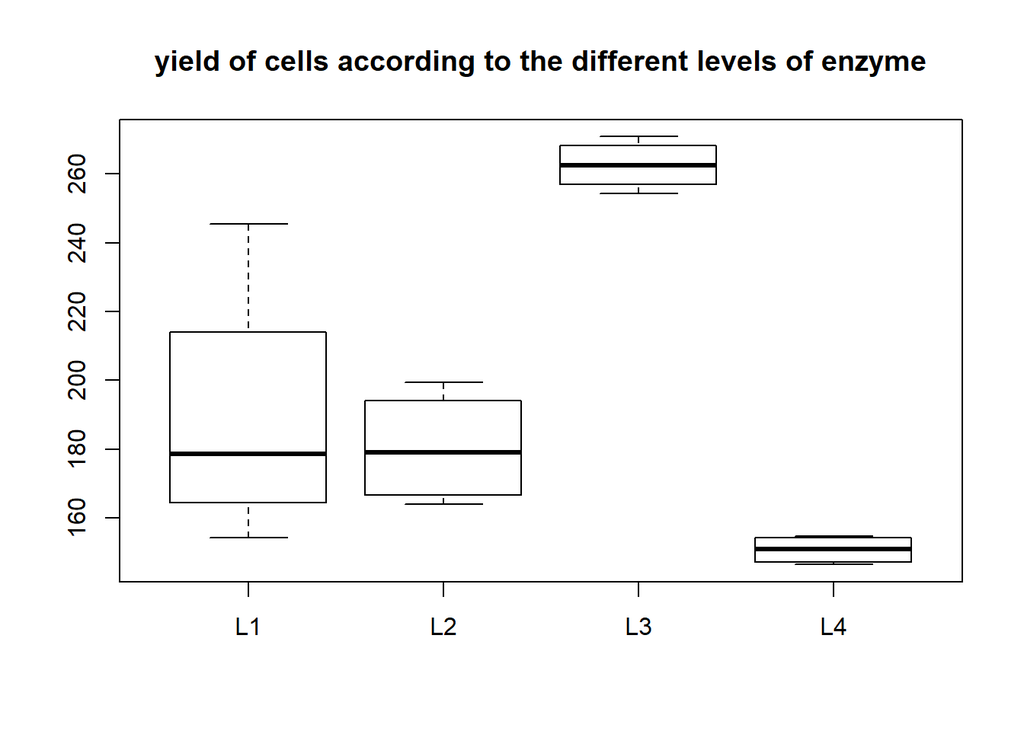

```r
boxplot(Response ~ Treatments, data = data,
        main = "yield of cells according to the different levels of enzyme")
```

```r
# ANOVA Analysis
fit <- aov(Response ~ Block + Treatments, data = data)
summary(fit)
```

```
##             Df Sum Sq Mean Sq F value   Pr(>F)
## Block        3   2056     685   1.704 0.235212
## Treatments   3  27061    9020  22.430 0.000164 ***
## Residuals    9   3619     402
## ---
## Signif. codes:  0 '***' 0.001 '**' 0.01 '*' 0.05 '.' 0.1 ' ' 1
```

```r
TukeyHSD(fit)
```

```
##   Tukey multiple comparisons of means
##     95% family-wise confidence level
##
## Fit: aov(formula = Response ~ Block + Treatments, data = data)
##
## $Block
##            diff       lwr      upr     p adj
## C2-C1 -9.053601 -53.32113 35.21393 0.9169163
## C3-C1 -5.286321 -49.55385 38.98121 0.9812200
## C4-C1 20.322413 -23.94511 64.58994 0.5114975
## C3-C2  3.767280 -40.50025 48.03481 0.9929717
## C4-C2 29.376014 -14.89151 73.64354 0.2328807
## C4-C3 25.608734 -18.65879 69.87626 0.3307793
##
## $Treatments
##              diff        lwr        upr     p adj
## L2-L1   -8.836308  -53.10384  35.431219 0.9220641
## L3-L1   73.296817   29.02929 117.564344 0.0026915
## L4-L1  -38.510299  -82.77783   5.757228 0.0919670
## L3-L2   82.133125   37.86560 126.400652 0.0012181
## L4-L2  -29.673991  -73.94152  14.593536 0.2262619
## L4-L3 -111.807116 -156.07464 -67.539589 0.0001189
```

```r
# cf
anova(lm(Response ~ Block + Treatments, data = data))
```

```
## Analysis of Variance Table
##
## Response: Response
##            Df  Sum Sq Mean Sq F value    Pr(>F)
## Block       3  2055.9   685.3   1.704 0.2352124
## Treatments  3 27060.8  9020.3  22.430 0.0001636 ***
## Residuals   9  3619.4   402.2
## ---
## Signif. codes:  0 '***' 0.001 '**' 0.01 '*' 0.05 '.' 0.1 ' ' 1
```

Blocks are usually treated as random effects, as they would represent the population of all possible blocks. In other words, we are usually not concerned with mean comparisons among specific blocks, but are using blocks to represent the population of all possible blocks. To more clearly understand this concept, I strongly recommend you watch [*this video*](https://www.youtube.com/watch?v=POqEf3FqaGc)

#### Latin Square design (s6)

A Latin Square design is an example of an incomplete block design where there is a single treatment and two blocking variables, each with the same number of levels. In the latin square design, only a single treatment is applied within each combination of blocking variables. In addition, each letter appears in each row and in each column exactly once. There are many different possible Latin Squares of a given size and For any Latin square, swapping the order of the rows or the columns provides a different Latin square. Latin square design for our example is shown below.

3. A Latin Square design testing 4 enzymes with the same sample size and cell types as above.

```r
# Design
set.seed(123)
# Latin Square function
latin <- function (n, nrand = 20)
  {
  x = matrix(LETTERS[1:n], n, n)
  x = t(x)
  for (i in 2:n) x[i, ] = x[i, c(i:n, 1:(i - 1))]
  if (nrand > 0) {
    for (i in 1:nrand) {
      x = x[sample(n), ]
      x = x[, sample(n)]
    }
    }
  x
  }

rep <- latin(4)
rep[rep == "A"] <- "L1"
rep[rep == "B"] <- "L2"
rep[rep == "C"] <- "L3"
rep[rep == "D"] <- "L4"

colnames(rep) <- c("C1", "C2", "C3", "C4") # type of cells
rownames(rep) <- c("E1", "E2", "E3", "E4") # type of enzymes
knitr::kable(rep)
```

|  | C1 | C2 | C3 | C4 |
| --- | --- | --- | --- | --- |
| E1 | L3 | L1 | L2 | L4 |
| E2 | L2 | L4 | L1 | L3 |
| E3 | L1 | L3 | L4 | L2 |
| E4 | L4 | L2 | L3 | L1 |

In Latin square design, the blocking variables are two. Therefore, we need to consider two blocking variables at the same time as shown below.

```r
data <- rbind(cbind(rep("E1", 4), paste0("C",1:4), c("L3", "L1", "L2", "L4")),
              cbind(rep("E2", 4), paste0("C",1:4), c("L2", "L4", "L1", "L3")),
              cbind(rep("E3", 4), paste0("C",1:4), c("L1", "L3", "L4", "L2")),
              cbind(rep("E4", 4), paste0("C",1:4), c("L4", "L2", "L3", "L1")))

# Data
data <- as.data.frame(data)
data[data[,3] == "L1",4] <- runif(4, min = 150, max = 250)
data[data[,3] == "L2",4] <- runif(4, min = 100, max = 200)
data[data[,3] == "L3",4] <- runif(4, min = 200, max = 300)
data[data[,3] == "L4",4] <- runif(4, min = 145, max = 155)
colnames(data) <- c("Enzyme_type", "Cell_types", "Levels", "yield")
colnames(data) <- c("Block1", "Block2", "Treatments", "Response")
str(data)
```

```
## 'data.frame':    16 obs. of  4 variables:
##  $ Block1    : Factor w/ 4 levels "E1","E2","E3",..: 1 1 1 1 2 2 2 2 3 3 ...
##  $ Block2    : Factor w/ 4 levels "C1","C2","C3",..: 1 2 3 4 1 2 3 4 1 2 ...
##  $ Treatments: Factor w/ 4 levels "L1","L2","L3",..: 3 1 2 4 2 4 1 3 1 3 ...
##  $ Response  : num  241 200 136 154 153 ...
```

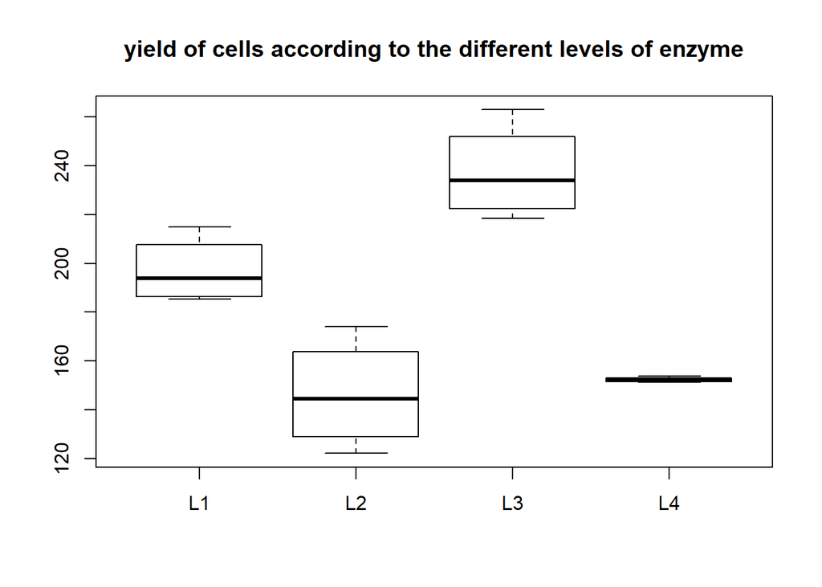

```r
boxplot(Response ~ Treatments, data = data,
        main = "yield of cells according to the different levels of enzyme")
```

```r
# ANOVA Analysis
fit <- aov(Response ~ Treatments + Block1 + Block2, data = data)
summary(fit)
```

```
##             Df Sum Sq Mean Sq F value   Pr(>F)
## Treatments   3  21765    7255  80.759 3.06e-05 ***
## Block1       3   2034     678   7.548   0.0185 *
## Block2       3    659     220   2.446   0.1618
## Residuals    6    539      90
## ---
## Signif. codes:  0 '***' 0.001 '**' 0.01 '*' 0.05 '.' 0.1 ' ' 1
```

```r
TukeyHSD(fit)
```

```
##   Tukey multiple comparisons of means
##     95% family-wise confidence level
##
## Fit: aov(formula = Response ~ Treatments + Block1 + Block2, data = data)
##
## $Treatments
##             diff        lwr       upr     p adj
## L2-L1 -50.758316  -73.95883 -27.55781 0.0011366
## L3-L1  40.283277   17.08277  63.48379 0.0038752
## L4-L1 -44.781295  -67.98181 -21.58078 0.0022279
## L3-L2  91.041593   67.84108 114.24210 0.0000415
## L4-L2   5.977021  -17.22349  29.17753 0.8097381
## L4-L3 -85.064572 -108.26508 -61.86406 0.0000618
##
## $Block1
##             diff        lwr       upr     p adj
## E2-E1  -3.222987 -26.423497 19.977524 0.9605895
## E3-E1  18.256639  -4.943871 41.457150 0.1198675
## E4-E1 -12.885208 -36.085718 10.315303 0.3115406
## E3-E2  21.479626  -1.720885 44.680136 0.0674617
## E4-E2  -9.662221 -32.862731 13.538290 0.5210716
## E4-E3 -31.141847 -54.342357 -7.941336 0.0138293
##
## $Block2
##              diff       lwr       upr     p adj
## C2-C1  -5.7547164 -28.95523 17.445794 0.8255475
## C3-C1 -17.4553525 -40.65586  5.745158 0.1384964
## C4-C1  -4.7780399 -27.97855 18.422471 0.8885388
## C3-C2 -11.7006362 -34.90115 11.499874 0.3798203
## C4-C2   0.9766765 -22.22383 24.177187 0.9987706
## C4-C3  12.6773127 -10.52320 35.877823 0.3227538
```

```r
# cf
anova(lm(Response ~ Treatments + Block1 + Block2, data = data))
```

```
## Analysis of Variance Table
##
## Response: Response
##            Df  Sum Sq Mean Sq F value    Pr(>F)
## Treatments  3 21764.8  7254.9 80.7588 3.059e-05 ***
## Block1      3  2034.3   678.1  7.5482   0.01845 *
## Block2      3   659.2   219.7  2.4460   0.16176
## Residuals   6   539.0    89.8
## ---
## Signif. codes:  0 '***' 0.001 '**' 0.01 '*' 0.05 '.' 0.1 ' ' 1
```

#### Factorial design (s6)

Factorial design is a design consists of two or more factors, each with discrete possible values or “levels”, and whose experimental units take on all possible combinations of these levels across all such factors. If the design contains all possible combinations of the levels, we call them crossed.

4. How many experimental units are you need to make the design of 4 enzymes, 4 levels, 4 types of cells with 3 replicates be complete design?

The question above illustrates fully crossed design. The possible configurations of this design is given as below.

$$N = n_i \times n_j \times n_k \times n_r$$

where $N$ is the total number of experimental units, $n_i$, $n_j$, $n_k$ are the number of levels on the first, second and third factors respectively. Because we have 4, 4, 4 factors and 3 replicates, the number of experimental units is 192. In other words, to test the factorial design in our experimental setting, we need to culture 192 cells on different dishes.

```r
# Design
set.seed(123)
n <- 4 * 4 * 4 * 3
dish <- 1:n
enzyme_types <- rep(c("E1","E2","E3","E4"), n/4)
levels <- rep(c("L1","L2","L3","L4"), n/4)
cell_types <- rep(c("C1","C2","C3","C4"), n/4)
replicate <- rep(c("R1", "R2", "R3"), n/3)
data <- data.frame(dish, sample(enzyme_types),
                   sample(cell_types), sample(levels), replicate)
```

In factorial design, we need to consider interaction effect of two or more blocking variables as shown below.

```r
# data
data[data[,4] == "L1",6] <- runif(n/4, min = 150, max = 250)
data[data[,4] == "L2",6] <- runif(n/4, min = 100, max = 200)
data[data[,4] == "L3",6] <- runif(n/4, min = 200, max = 300)
data[data[,4] == "L4",6] <- runif(n/4, min = 145, max = 155)

colnames(data) <- c("Dishes", "Block1", "Block2",
                    "Treatments", "Replicate", "Response"); head(data)
```

```
##   Dishes Block1 Block2 Treatments Replicate Response
## 1      1     E4     C2         L4        R1 149.1867
## 2      2     E3     C3         L3        R2 208.6278
## 3      3     E2     C3         L4        R3 152.1788
## 4      4     E3     C1         L2        R1 104.2108
## 5      5     E1     C1         L2        R2 136.4411
## 6      6     E1     C4         L4        R3 152.4254
```

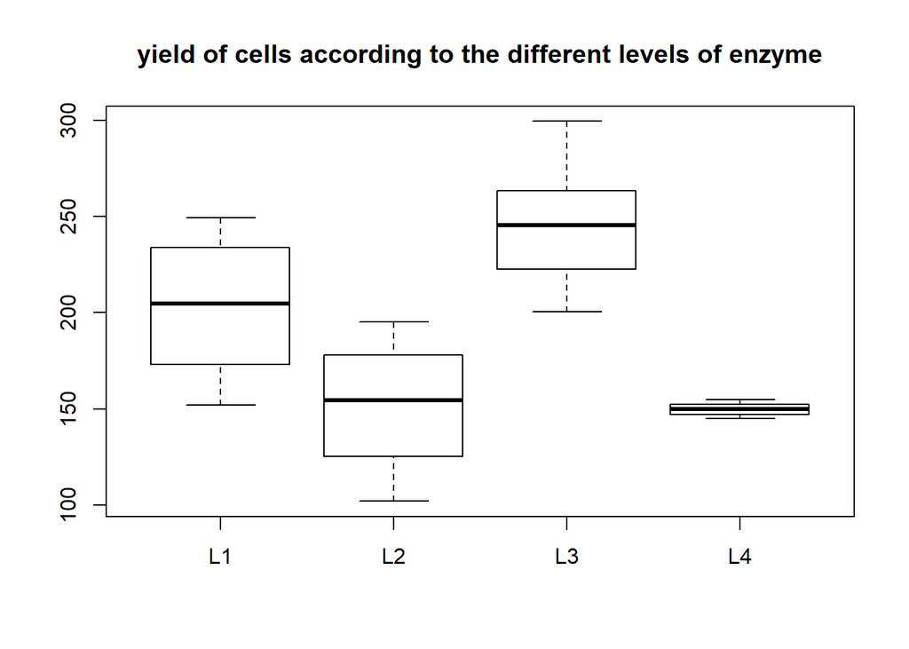

```r
boxplot(Response ~ Treatments, data = data,
        main = "yield of cells according to the different levels of enzyme")
```

```r
# ANOVA Analysis
fit <- aov(Response ~ Treatments + Block1 * Block2 + Replicate, data = data)
summary(fit)
```

```
##                Df Sum Sq Mean Sq F value Pr(>F)
## Treatments      3 300075  100025 151.327 <2e-16 ***
## Block1          3   1660     553   0.837  0.475
## Block2          3   2646     882   1.334  0.265
## Replicate       2   1655     827   1.252  0.289
## Block1:Block2   9   6771     752   1.138  0.338
## Residuals     171 113029     661
## ---
## Signif. codes:  0 '***' 0.001 '**' 0.01 '*' 0.05 '.' 0.1 ' ' 1
```

```r
TukeyHSD(fit)$Treatments
```

```
##             diff        lwr       upr        p adj
## L2-L1 -50.859645  -64.47535 -37.24394 2.298162e-14
## L3-L1  42.720026   29.10432  56.33573 4.958256e-13
## L4-L1 -52.538916  -66.15462 -38.92321 2.364775e-14
## L3-L2  93.579671   79.96397 107.19537 0.000000e+00
## L4-L2  -1.679271  -15.29497  11.93643 9.886316e-01
## L4-L3 -95.258942 -108.87465 -81.64324 0.000000e+00
```

As you can see, only treatment effect is significant in this example.

#### Relationship between ANOVA, Experimental Design and Regression (s6)

Let’s formalize our observation as follows. Suppose you have several observations, say $Y_{ij}$, and it follows normal distribution with mean $\mu_i$ and variance $\sigma^2$ which assume that equal variance for all observations. Now we can write,
$$Y_{ij} \sim i.i.d.\ N(\mu_i, \sigma^2)$$
where $i = 1,...,k$ represents different treatment groups and $j=1,...,n$ represents number of samples in each group. we can rewrite the above relationship as
$$Y_{ij} = \mu_i + \epsilon_{ij}, \ \ \epsilon_{ij} \sim i.i.d \ N(0, \sigma^2)$$

which means the random errors of all observations follow normal distribution with mean $0$ and variance $\sigma^2$. In other words, our observations are simply drawn by the deterministic statistic $\mu_i$ and a stochastic error $\epsilon_{ij}$ fluctuating around zero (which means $\sum_{j=1}^n \epsilon_{ij} = 0$). We also say that $Y$ is the **response variable** and the grouping information is **predictor variables**. That is a linear regression model with a categorical pedictor with normally distributed errors.

We can rewrite $\mu_i$ as
$$\mu_i = \mu + \alpha_i$$
for $i = 1,...,k$ to obtain
$$Y_{ij} = \mu + \alpha_i + \epsilon_{ij}$$
where

- $\epsilon_{ij} \sim i.i.d. \ N(0, \sigma^2)$
- $\mu = \frac{1}{k} \sum_{i=1}^{k}\mu_i$
- $\sum_{i=1}^{k}\alpha_i = 0$

Here $\alpha_i$ represents the $i_{th}$ *treatment effect* and we assumed sum of all treatment effect is zero (or you can use $\alpha_1 = 0$ as a side-constraint. This is default constraint of R. because we have k+1 parameters with k equations, to estimate $\mu_i$ we need to have this side-constraint equation). Think of $\mu$ as a *“grand mean”* and $\alpha_i$ as a *“deviation from the grand mean due to the $i_{th}$ treatment effect”* This statement is not always correct but it is still useful.

We now estimate the parameters using the least squares criterion which ensures that the model fits the data well in the sense that the squared deviation from the observed data $y_{ij}$ to the model values $\mu + \alpha_i$ are minimized, i.e.,
$$\hat \mu, \hat \alpha_i = argmin_{\mu, \alpha_i} \sum_{i=1}^{k}\sum_{j=1}^{n} (y_{ij} - \mu - \alpha_i)^2$$
or simply
$$\hat \mu_i = argmin_{\mu_i}\sum_{i=1}^{k}\sum_{j=1}^{n} (y_{ij} - \mu_i)^2$$
As we can independently estimate the values of the different groups, we get $\hat \mu_i = \bar y_i.$, hence
$$\hat \mu_i = \hat \mu + \hat \alpha_i = \bar y_i.$$
where
$$\bar y_{i.} = \frac{1}{n}\sum_{j=1}^{n} y_{ij} \hspace {1cm} mean \ \ of \ \ group \ \ i$$

Depnding on the side-constriant that we use we get different results for $\hat \alpha_i$

The estimate of the error variance $\hat \sigma^2$ is also called **mean squared error, MSE**. It is given by
$$\hat \sigma^2 = MSE = \frac{1}{N-k} SSE$$
where
$$SSE = \sum_{i=1}^{k}\sum_{j=1}^{n} (y_{ij} - \hat\mu_i)^2 \hspace {1cm} \ total \ sum \ of \ squares$$
With these definitions, we can generate testing hypothesis as shown below.

$$H_0: \mu_1 = ... \mu_k$$
$$H_A: \mu_k \neq \mu_l \ for \ \ at \ \ least \ \ one \ \ pair \ \ k \neq l$$

By constructing a statistical test through decomposing the variation of the data, we can test our hypothesis. Here we test whether total variance of the response around the overall mean originated from the variance *“between groups”* or the variance *“within groups”*. Formally,

where

$$y_{i.} = \sum_{j=1}^{n} y_{ij} \hspace {1cm} sum \ \ of \ \ group \ \ i$$

$$y_{..} = \sum_{i=1}^{k}\sum_{j=1}^{n} y_{ij} \hspace {1cm} sum \ \ of \ \ all \ \ observations$$

$$\bar y_{i.} = \frac{1}{n}\sum_{j=1}^{n} y_{ij} \hspace {1cm} mean \ \ of \ \ group \ \ i$$

$$\bar y_{..} = \frac{1}{N} \sum_{i=1}^{k}\sum_{j=1}^{n} y_{ij} \hspace {1cm} overall \ \ (or \ \ total) \ \ mean$$

If all the groups share the same (theoretical) mean, we expect the treatment sum of squares to be small: Just due to the random nature of the data we expect small differences between the different (empirical) group means. The idea is now to compare the variation between groups with the variation within groups. If the variation between groups is substantially larger than the variation within groups we have evidence against the null hypothesis.

In fact, it can be shown that under $H_0$, it holds that

$$F = \frac{MSTr}{MSE} ~ F_{k-1, N-k}$$
where
$$MSTr = \frac{SSTr}{k-1} \hspace {1cm} Mean \ \ squares \ \ of \ \ treatments$$
$$MSE = \frac{SSE}{N-k} \hspace {1cm} Mean \ \ squares \ \ of \ \ errors$$

So far we derived equations to model our observation and derive test statistics. When we get these statistics from our data, we need to check validity of these statistics by checking assumptions underlying our model. This is called the **Residual Analysis**. The assumptions we made is expressed as $\epsilon_{ij} \sim i.i.d. \ N(0, \sigma^2)$. We can not test our assumption directly, because we can not observe the error. Instead we can estimate the error using *residuals* represented as
$$r_{ij} = y_{ij} - \hat \mu_i$$

In R, there are some of tools related to this residual. *Q-Q plot* can show the fitness of the model compared to the theoretical model derived from reference distribution (the default is normal distribution). *TA-Plot (Tukey-Anscombe Plot)* can show whether residuals have constant variance and zero mean. *Index plot* can show sequential structure of residuals. These are tools for checking our model. You can plot these tools by simply run plot function on the fitted model.

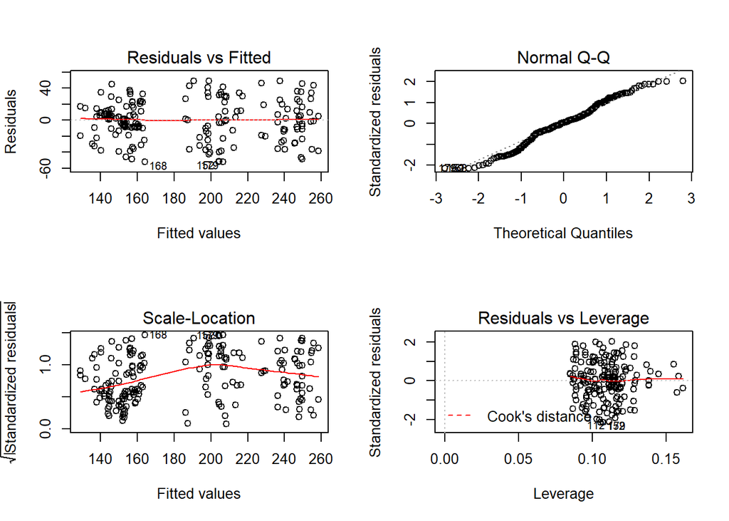

```r
par(mfrow=c(2,2)); plot(fit); par(mfrow=c(1,1))
```

This is called **Analysis of Variance** or **ANOVA**.

Recall we started from equation
$$Y_{ij} = \mu + \alpha_i + \epsilon_{ij}$$
In fact, the equation is equivalent to the equation of **completely randomized design** or *CRD*. If you add blocking variable to the this equation, then you can get the **Randomized complete block design** or *RCBD* and formally,

$$y_{ij} = \mu + \alpha_i + \beta_j + e_{ij}, \ \ \ j = 1,...,n_i \ \ i = 1, ..., k$$
where

- $\mu$ is an overall mean
- $\alpha_{i}$ is the effect of treatment $i$ where $\sum_{i=1} \alpha_i = 0$, for $i = 1, ..., n$
- $\beta_{j}$ is the effect of block $j$ where $\sum_{j=1} \beta_j = 0$, for $i = 1, ..., k$
- and $e_{ij} \sim i.i.d \ N(0,\sigma_e^2)$ is individual random error

Note that $\mu_{ij} = \mu + \alpha_i + \beta_j$. We could assume $\alpha_1 = \beta_1 = 0$

If you have two blocking variable with equal size then you can apply **Latin Square design** and formally,

$$y_{ijk} = \mu + \alpha_i + \beta_j + \gamma_k + \epsilon_{ijk}$$

where,

- $\mu$ is a population mean
- $\alpha_i$ is the main effect of treatment $i$, $i = 1,2, ..., n$, $\sum_{i=1}^n \alpha_i = 0$
- $\beta_j$ is a main effect of the first blocking variable $j$, $j=1, 2, ..., n$, $\sum_{j=1}^n \beta_j = 0$
- $\gamma_k$ is a main effect of the second blocking variable $k$, $k=1, 2, ..., n$, $\sum_{k=1}^n \gamma_k = 0$
- $\epsilon_{ijk} ~ i.i.d. \ N(0, \sigma_{\epsilon}^2)$ is the individual error distribution

For the factorial design, we simply add interaction term as shown below

$$y_{ij} = \mu + \alpha_i + \beta_j + (\alpha\beta)_{ij} + e_{ijk}, \ \ \ j = 1,...,n_i \ \ i = 1, ..., k$$
Note that although it looks like a multiplication, the interaction term need not imply multiplicative interaction.

You can extend this model with more than 2 factors by writing as
$$y_{ij} = \mu + \alpha_i + \beta_j + \gamma_k + (\alpha\beta)_{ij} + (\alpha\gamma)_{ik} + (\beta\gamma)_{jk} + e_{ijkl}, \ \ \ i = 1,...,a, \ \ j = 1, ..., b, \ \ k=1,...,c, \ \ l = 1,...,n$$

You can also write the equation $Y_{ij} = \mu + \alpha_i + \epsilon_{ij}$ in matrix notation as
$$Y = X\beta + E$$
where

- $Y \in R^N$ contains all the response values,
- $X$ is an $N \times k$ matrix, the so-called **design matrix**,
- $\beta \in R^k$ contains all parameters and
- $E \in R^N$ are the error terms.

This is a typical setup for any regression problem.

In sumamry, ANOVA, Design of experiment, and Regression are essentially the same analysis but different representations and purposes. In our example, the regression model utilizes a categorical predictors.